# Midterm Decision

- Show All Code
- Hide All Code

Course MATH 425

Author

Lexi Soelberg

```r
M425P1 <- M425P %>%
  filter(AttendedAlmostAlways == "Y", ClassActivitiesCompletedPerfectly == "Y", SkillsQuizzesCompletedPerfectly == "Y", MagicTwoGroups == 2,
)


M425P2 <- M425P %>%
  filter(AttendedAlmostAlways == "Y", ClassActivitiesCompletedPerfectly == "Y", SkillsQuizzesCompletedPerfectly == "Y", MagicTwoGroups == 2, Midterm != 52
)
```

### Decision: Keep My Midterm Score

# Analysis

**Cubic Model**

### Graph

```r
library(ggplot2)
library(plotly)

midpred.lm <- lm(FinalExam ~ Midterm + I(Midterm^2) + I(Midterm^3), data = M425P2)
b <- coef(midpred.lm)


predintv <- predict(midpred.lm, data.frame(Midterm = 68), interval = "prediction")
confintv <- predict(midpred.lm, data.frame(Midterm = 68), interval = "confidence")

midterm.ggplot <- ggplot(M425P2, aes(y = FinalExam, x = Midterm, color = FinalExam)) +
  geom_point(pch = 16, bg = "white", size = 3) +
  stat_function(fun=function(x) b[1] + b[2]*x + b[3]*x^2 + b[4]*x^3, color = "seagreen3", size = 1.5) +
  scale_color_gradient(low = "cadetblue1", high = "cadetblue4") +
  labs(
    title = "How Well Does My Midterm Predict My Final Exam?<br><sup>Let's Goooo<sup>",
    x = "Past Midterm Scores (2019-2024)",
    y = "Past Final Exam Scores (2019-2024)"
  ) +
  ylim(min(M425P2$FinalExam) - 5, max(M425P2$FinalExam) + 5) +
  theme_minimal() +
  geom_point(
    aes(x = 68, y = predict(midpred.lm, data.frame(Midterm = 68))),
    color = "firebrick", size = 4
  ) +
  geom_text(
    aes(x = 68, y = predict(midpred.lm, data.frame(Midterm = 68)), label = "Predicted Final Exam Score"),
    color = "firebrick", nudge_x = -11.25, size = 3
  ) +
  geom_segment(aes(x=68, xend=68, y=confintv[2], yend=confintv[3]),
               alpha=0.04, color="goldenrod2", lwd=2) +
  geom_segment(aes(x=68, xend=68, y=predintv[2], yend=predintv[3]),
               alpha=0.009, color="firebrick", lwd=1.5)

ggplotly(midterm.ggplot, tooltip = c("x", "y"))
```

[interactive chart not shown]

### Cubic Regression

```r
midpred.lm <- lm(FinalExam ~ Midterm + I(Midterm^2) + I(Midterm^3), data = M425P2)

pander(summary(midpred.lm))
```

|  | Estimate | Std. Error | t value | Pr(>\|t\|) |
| --- | --- | --- | --- | --- |
| **(Intercept)** | 165.3 | 78.66 | 2.101 | 0.04382 |
| **Midterm** | -6.294 | 3.941 | -1.597 | 0.1204 |
| **I(Midterm^2)** | 0.1066 | 0.06157 | 1.732 | 0.0933 |
| **I(Midterm^3)** | -0.0005145 | 0.0003048 | -1.688 | 0.1015 |

Fitting linear model: FinalExam ~ Midterm + I(Midterm^2) + I(Midterm^3)

| Observations | Residual Std. Error | $R^2$ | Adjusted $R^2$ |
| --- | --- | --- | --- |
| 35 | 9.366 | 0.5303 | 0.4849 |

#### Checking for Correctness

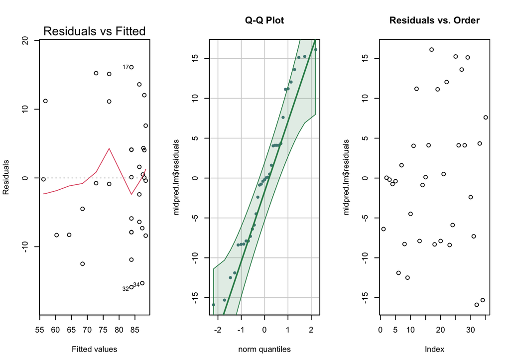

```r
par(mfrow=c(1,3))

plot(midpred.lm, which=1)

qqPlot(midpred.lm$residuals, main="Q-Q Plot", col="cadetblue4", col.lines="seagreen", pch= 19, id=FALSE)

plot(midpred.lm$residuals, main = "Residuals vs. Order")
```

Everything looks fairly good.

There are 5 associated assumptions to the linear regression. All but #4 can be checked with these above plots.

**Assumption 1: Linear Relationship Between X and Y**

The linearity as shown in the residuals/fitted plot is a little wonky but it evens out. This is due to the dots being on the right side with more linearity than the left side.

**Assumption 2: Normal Distribution of Error Terms**

Most of the dots as shown in the Q-Q plot fall on or close to the line, there are a few at the top that vary from normality but this isn’t too bad.

**Assumption 3: Constant Variance (X values)**

We do see a push of the data to higher values. The right side is more occupied that the left. Constant variance is put into question here.

**Assumption 4: Fixed X**

The $X_i$ values can be considered fixed and measured without error.

**Assumption 5: Independent Error Terms**

The Residuals vs Order plot shows the chaos in the data. Error terms do not appear to be correlated. There is not a clear pattern in the plot.

**Assumption Conclusion**

There is not sufficient evidence shown in the above plots to discredit the whole linear regression analysis.

### Prediction

```r
library(pander)

# Prediction Interval
predintv <- predict(midpred.lm, data.frame(Midterm = 68), interval = "prediction")
pander(data.frame(`Prediction Interval` = predintv))
```

| Prediction.Interval.fit | Prediction.Interval.lwr | Prediction.Interval.upr |
| --- | --- | --- |
| 68.49 | 48.43 | 88.55 |

```r
# Confidence Interval
confintv <- predict(midpred.lm, data.frame(Midterm = 68), interval = "confidence")
pander(data.frame(`Confidence Interval` = confintv))
```

| Confidence.Interval.fit | Confidence.Interval.lwr | Confidence.Interval.upr |
| --- | --- | --- |
| 68.49 | 62.37 | 74.6 |

### Final Decision

**The big question is then what if I get exactly my prediction? What will my final score be?**

```r
pander(paste(0.7*68.49 + 0.3*68))
```

68.343

**The prediction intervals:**

**High** *(0.3 x 68 + 0.7 x 88.55)*

```r
pander(paste(+ 0.3*68 + 0.7*88.55))
```

82.385

**Low** *(0.3 x 68 + 0.7 x 48.43)*

```r
pander(paste(0.3*68 + 0.7*48.43))
```

54.301

If I go based off my final exam prediction I am likely to get a 68 but accounting for prediction intervals, I have a range of plus or minus 20 points. I believe I will be more confident in my final exam score with the addition of my midterm. 68 wasn’t too bad to start out as the midterm. I have the chance to get an 88 on the final, bringing my overall exam score to an 82 but there’s also a chance to get a 48 on the final and that will bring my overall exam score to a 54.

**I am deciding to keep my midterm** and shoot for a higher score than 68 on my final exam. I feel confident that I can aim for a 76. If I got a 76 on the final my overall exam grade would be a 74.

**Appendix**

### Residual 21

First of all: When examining the original residulas plots as well as the graph, there was an extreme outlier. Someone who got a 52 on the midterm and a 92 on the final exam. It was pulling the data away like crazy. It is number 21 as shown below. I removed that dot from the analysis. It made the $R^2$ for all models significantly better.

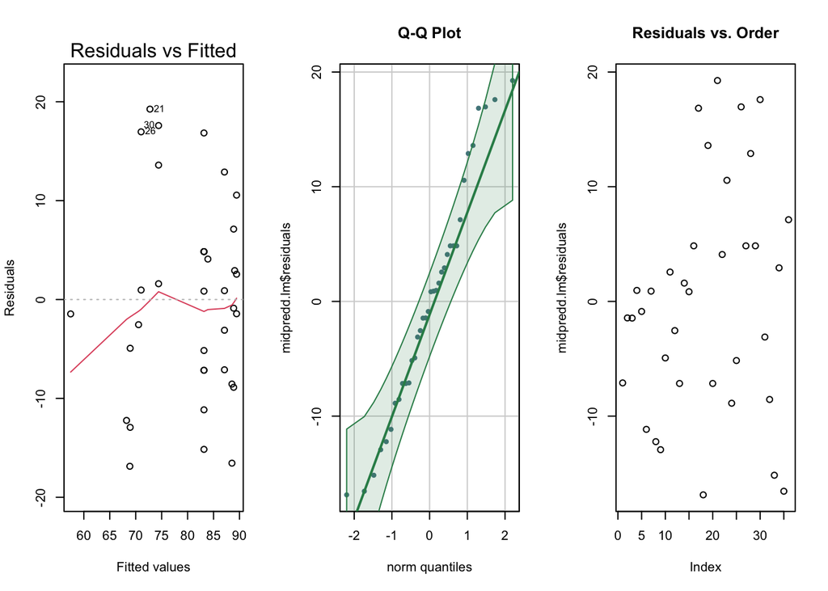

```r
midpredd.lm <- lm(FinalExam ~ Midterm + I(Midterm^2) + I(Midterm^3) + I(Midterm^4), data = M425P1)

par(mfrow=c(1,3))

plot(midpredd.lm, which=1)

qqPlot(midpredd.lm$residuals, main="Q-Q Plot", col="cadetblue4", col.lines="seagreen", pch= 19, id=FALSE)

plot(midpredd.lm$residuals, main = "Residuals vs. Order")
```

#### Confidence Intervals

**How about if I get the high end of my confidence interval?**

```r
pander(paste(0.7*74.6 + 0.3*68))
```

72.62

**The low end?**

```r
pander(paste(0.7*62.37 + 0.3*68))
```

64.059

### Other Models

**The Simple Model**

The $R^2$ was low for this one so I moved to a quadratic:

```r
midpred1.lm <- lm(FinalExam ~ Midterm, data = M425P2)

pander(summary(midpred1.lm))
```

|  | Estimate | Std. Error | t value | Pr(>\|t\|) |
| --- | --- | --- | --- | --- |
| **(Intercept)** | 26.14 | 9.921 | 2.635 | 0.01273 |
| **Midterm** | 0.6671 | 0.1203 | 5.543 | 3.712e-06 |

Fitting linear model: FinalExam ~ Midterm

| Observations | Residual Std. Error | $R^2$ | Adjusted $R^2$ |
| --- | --- | --- | --- |
| 35 | 9.532 | 0.4822 | 0.4665 |

```r
library(ggplot2)
library(plotly)

midpred1.lm <- lm(FinalExam ~ Midterm, data = M425P2)
b <- coef(midpred1.lm)


predintv <- predict(midpred1.lm, data.frame(Midterm = 68), interval = "prediction")
confintv <- predict(midpred1.lm, data.frame(Midterm = 68), interval = "confidence")

midterm.ggplot <- ggplot(M425P2, aes(y = FinalExam, x = Midterm, color = FinalExam)) +
  geom_point(pch = 16, bg = "white", size = 3) +
  stat_function(fun=function(x) b[1] + b[2]*x, color = "seagreen3", size = 1.5) +
  scale_color_gradient(low = "cadetblue1", high = "cadetblue4") +
  labs(
    title = "How Well Does My Midterm Predict My Final Exam?<br><sup>Let's Goooo<sup>",
    x = "Past Midterm Scores (2019-2024)",
    y = "Past Final Exam Scores (2019-2024)"
  ) +
  ylim(min(M425P2$FinalExam) - 5, max(M425P2$FinalExam) + 5) +
  theme_minimal() +
  geom_point(
    aes(x = 68, y = predict(midpred.lm, data.frame(Midterm = 68))),
    color = "firebrick", size = 4
  ) +
  geom_text(
    aes(x = 68, y = predict(midpred.lm, data.frame(Midterm = 68)), label = "Predicted Final Exam Score"),
    color = "firebrick", nudge_x = -11.25, size = 3
  ) +
  geom_segment(aes(x=68, xend=68, y=confintv[2], yend=confintv[3]),
               alpha=0.04, color="goldenrod2", lwd=2) +
  geom_segment(aes(x=68, xend=68, y=predintv[2], yend=predintv[3]),
               alpha=0.009, color="firebrick", lwd=1.5)

ggplotly(midterm.ggplot, tooltip = c("x", "y"))
```

[interactive chart not shown]

```r
predintv1 <- predict(midpred1.lm, data.frame(Midterm = 68), interval = "prediction")
pander(data.frame(`Prediction Interval` = predintv1))
```

| Prediction.Interval.fit | Prediction.Interval.lwr | Prediction.Interval.upr |
| --- | --- | --- |
| 71.5 | 51.56 | 91.44 |

```r
# Confidence Interval
confintv1 <- predict(midpred1.lm, data.frame(Midterm = 68), interval = "confidence")
pander(data.frame(`Confidence Interval` = confintv1))
```

| Confidence.Interval.fit | Confidence.Interval.lwr | Confidence.Interval.upr |
| --- | --- | --- |
| 71.5 | 66.87 | 76.13 |

**The Quadratic Model**

The $R^2$ was almost worse for this one so I moved to a cubic:

```r
midpred2.lm <- lm(FinalExam ~ Midterm + I(Midterm^2), data = M425P2)

pander(summary(midpred2.lm))
```

|  | Estimate | Std. Error | t value | Pr(>\|t\|) |
| --- | --- | --- | --- | --- |
| **(Intercept)** | 40.68 | 27.87 | 1.46 | 0.1541 |
| **Midterm** | 0.2291 | 0.7926 | 0.2891 | 0.7744 |
| **I(Midterm^2)** | 0.003103 | 0.005549 | 0.5592 | 0.5799 |

Fitting linear model: FinalExam ~ Midterm + I(Midterm^2)

| Observations | Residual Std. Error | $R^2$ | Adjusted $R^2$ |
| --- | --- | --- | --- |
| 35 | 9.633 | 0.4872 | 0.4551 |

```r
library(ggplot2)
library(plotly)

midpred2.lm <- lm(FinalExam ~ Midterm + I(Midterm^2), data = M425P2)
b <- coef(midpred2.lm)


predintv <- predict(midpred2.lm, data.frame(Midterm = 68), interval = "prediction")
confintv <- predict(midpred2.lm, data.frame(Midterm = 68), interval = "confidence")

midterm.ggplot <- ggplot(M425P2, aes(y = FinalExam, x = Midterm, color = FinalExam)) +
  geom_point(pch = 16, bg = "white", size = 3) +
  stat_function(fun=function(x) b[1] + b[2]*x + b[3]*x^2, color = "seagreen3", size = 1.5) +
  scale_color_gradient(low = "cadetblue1", high = "cadetblue4") +
  labs(
    title = "How Well Does My Midterm Predict My Final Exam?<br><sup>Let's Goooo<sup>",
    x = "Past Midterm Scores (2019-2024)",
    y = "Past Final Exam Scores (2019-2024)"
  ) +
  ylim(min(M425P2$FinalExam) - 5, max(M425P2$FinalExam) + 5) +
  theme_minimal() +
  geom_point(
    aes(x = 68, y = predict(midpred.lm, data.frame(Midterm = 68))),
    color = "firebrick", size = 4
  ) +
  geom_text(
    aes(x = 68, y = predict(midpred.lm, data.frame(Midterm = 68)), label = "Predicted Final Exam Score"),
    color = "firebrick", nudge_x = -11.25, size = 3
  ) +
  geom_segment(aes(x=68, xend=68, y=confintv[2], yend=confintv[3]),
               alpha=0.04, color="goldenrod2", lwd=2) +
  geom_segment(aes(x=68, xend=68, y=predintv[2], yend=predintv[3]),
               alpha=0.009, color="firebrick", lwd=1.5)

ggplotly(midterm.ggplot, tooltip = c("x", "y"))
```

[interactive chart not shown]

```r
predintv2 <- predict(midpred2.lm, data.frame(Midterm = 68), interval = "prediction")
pander(data.frame(`Prediction Interval` = predintv2))
```

| Prediction.Interval.fit | Prediction.Interval.lwr | Prediction.Interval.upr |
| --- | --- | --- |
| 70.6 | 50.17 | 91.04 |

```r
# Confidence Interval
confintv2 <- predict(midpred2.lm, data.frame(Midterm = 68), interval = "confidence")
pander(data.frame(`Confidence Interval` = confintv2))
```

| Confidence.Interval.fit | Confidence.Interval.lwr | Confidence.Interval.upr |
| --- | --- | --- |
| 70.6 | 64.9 | 76.31 |

**The Quad (as in 4) Model**

The adjusted $R^2$ was getting worse and the $R^2$ was still low for this one so as I was deciding on the 4 beta model in my analysis I also tested what it would be with 5 and 6 betas:

*This is when it gets crazy:*

```r
midpred4.lm <- lm(FinalExam ~ Midterm + I(Midterm^2) + I(Midterm^3) + I(Midterm^4), data = M425P2)

pander(summary(midpred4.lm))
```

|  | Estimate | Std. Error | t value | Pr(>\|t\|) |
| --- | --- | --- | --- | --- |
| **(Intercept)** | 243.1 | 414.8 | 0.5859 | 0.5623 |
| **Midterm** | -11.66 | 28.36 | -0.411 | 0.684 |
| **I(Midterm^2)** | 0.2351 | 0.6756 | 0.348 | 0.7303 |
| **I(Midterm^3)** | -0.001811 | 0.006793 | -0.2666 | 0.7916 |
| **I(Midterm^4)** | 4.706e-06 | 2.463e-05 | 0.191 | 0.8498 |

Fitting linear model: FinalExam ~ Midterm + I(Midterm^2) + I(Midterm^3) + I(Midterm^4)

| Observations | Residual Std. Error | $R^2$ | Adjusted $R^2$ |
| --- | --- | --- | --- |
| 35 | 9.515 | 0.5309 | 0.4683 |

```r
library(ggplot2)
library(plotly)

midpred4.lm <- lm(FinalExam ~ Midterm + I(Midterm^2) + I(Midterm^3) + I(Midterm^4), data = M425P2)
b <- coef(midpred4.lm)


predintv <- predict(midpred4.lm, data.frame(Midterm = 68), interval = "prediction")
confintv <- predict(midpred4.lm, data.frame(Midterm = 68), interval = "confidence")

midterm.ggplot <- ggplot(M425P2, aes(y = FinalExam, x = Midterm, color = FinalExam)) +
  geom_point(pch = 16, bg = "white", size = 3) +
  stat_function(fun=function(x) b[1] + b[2]*x + b[3]*x^2 + b[4]*x^3 + b[5]*x^4, color = "seagreen3", size = 1.5) +
  scale_color_gradient(low = "cadetblue1", high = "cadetblue4") +
  labs(
    title = "How Well Does My Midterm Predict My Final Exam?<br><sup>Let's Goooo<sup>",
    x = "Past Midterm Scores (2019-2024)",
    y = "Past Final Exam Scores (2019-2024)"
  ) +
  ylim(min(M425P2$FinalExam) - 5, max(M425P2$FinalExam) + 5) +
  theme_minimal() +
  geom_point(
    aes(x = 68, y = predict(midpred.lm, data.frame(Midterm = 68))),
    color = "firebrick", size = 4
  ) +
  geom_text(
    aes(x = 68, y = predict(midpred.lm, data.frame(Midterm = 68)), label = "Predicted Final Exam Score"),
    color = "firebrick", nudge_y = -10, size = 3
  ) +
  geom_segment(aes(x=68, xend=68, y=confintv[2], yend=confintv[3]),
               alpha=0.04, color="goldenrod2", lwd=2) +

  geom_segment(aes(x=68, xend=68, y=predintv[2], yend=predintv[3]),
               alpha=0.01, color="firebrick", lwd=1.5)

ggplotly(midterm.ggplot, tooltip = c("x", "y"))
```

[interactive chart not shown]

```r
predintv4 <- predict(midpred4.lm, data.frame(Midterm = 68), interval = "prediction")
pander(data.frame(`Prediction Interval` = predintv4))
```

| Prediction.Interval.fit | Prediction.Interval.lwr | Prediction.Interval.upr |
| --- | --- | --- |
| 68.79 | 48.13 | 89.45 |

```r
# Confidence Interval
confintv4 <- predict(midpred4.lm, data.frame(Midterm = 68), interval = "confidence")
pander(data.frame(`Confidence Interval` = confintv4))
```

| Confidence.Interval.fit | Confidence.Interval.lwr | Confidence.Interval.upr |
| --- | --- | --- |
| 68.79 | 61.78 | 75.81 |

**The “Quinto” Model**

```r
midpred5.lm <- lm(FinalExam ~ Midterm + I(Midterm^2) + I(Midterm^3) + I(Midterm^4) + I(Midterm^5), data = M425P2)

pander(summary(midpred5.lm))
```

|  | Estimate | Std. Error | t value | Pr(>\|t\|) |
| --- | --- | --- | --- | --- |
| **(Intercept)** | -1887 | 2539 | -0.7434 | 0.4632 |
| **Midterm** | 165.5 | 210.2 | 0.7873 | 0.4375 |
| **I(Midterm^2)** | -5.346 | 6.596 | -0.8105 | 0.4243 |
| **I(Midterm^3)** | 0.08258 | 0.09944 | 0.8305 | 0.4131 |
| **I(Midterm^4)** | -0.0006128 | 0.0007263 | -0.8437 | 0.4057 |
| **I(Midterm^5)** | 1.759e-06 | 2.067e-06 | 0.8507 | 0.4019 |

Fitting linear model: FinalExam ~ Midterm + I(Midterm^2) + I(Midterm^3) + I(Midterm^4) + I(Midterm^5)

| Observations | Residual Std. Error | $R^2$ | Adjusted $R^2$ |
| --- | --- | --- | --- |
| 35 | 9.56 | 0.5423 | 0.4634 |

```r
library(ggplot2)
library(plotly)

midpred5.lm <- lm(FinalExam ~ Midterm + I(Midterm^2) + I(Midterm^3) + I(Midterm^4) + I(Midterm^5), data = M425P2)
b <- coef(midpred5.lm)


predintv <- predict(midpred5.lm, data.frame(Midterm = 68), interval = "prediction")
confintv <- predict(midpred5.lm, data.frame(Midterm = 68), interval = "confidence")

midterm.ggplot <- ggplot(M425P2, aes(y = FinalExam, x = Midterm, color = FinalExam)) +
  geom_point(pch = 16, bg = "white", size = 3) +
  stat_function(fun=function(x) b[1] + b[2]*x + b[3]*x^2 + b[4]*x^3 + b[5]*x^4 + b[6]*x^5, color = "seagreen3", size = 1.5) +
  scale_color_gradient(low = "cadetblue1", high = "cadetblue4") +
  labs(
    title = "How Well Does My Midterm Predict My Final Exam?<br><sup>Let's Goooo<sup>",
    x = "Past Midterm Scores (2019-2024)",
    y = "Past Final Exam Scores (2019-2024)"
  ) +
  ylim(min(M425P2$FinalExam) - 5, max(M425P2$FinalExam) + 5) +
  theme_minimal() +
  geom_point(
    aes(x = 68, y = predict(midpred.lm, data.frame(Midterm = 68))),
    color = "firebrick", size = 4
  ) +
  geom_text(
    aes(x = 68, y = predict(midpred.lm, data.frame(Midterm = 68)), label = "Predicted Final Exam Score"),
    color = "firebrick", nudge_x = -11.25, size = 3
  ) +
  geom_segment(aes(x=68, xend=68, y=confintv[2], yend=confintv[3]),
               alpha=0.04, color="goldenrod2", lwd=2) +
  geom_segment(aes(x=68, xend=68, y=predintv[2], yend=predintv[3]),
               alpha=0.009, color="firebrick", lwd=1.5)

ggplotly(midterm.ggplot, tooltip = c("x", "y"))
```

[interactive chart not shown]

The graph is basically saying that if you got a 40 on your midterm you are likely to get a 75 on the final. There aren’t any data points there so it is assuming that.

How about 6 betas?

```r
predintv5 <- predict(midpred5.lm, data.frame(Midterm = 68), interval = "prediction")
pander(data.frame(`Prediction Interval` = predintv5))
```

| Prediction.Interval.fit | Prediction.Interval.lwr | Prediction.Interval.upr |
| --- | --- | --- |
| 66.78 | 45.44 | 88.13 |

```r
# Confidence Interval
confintv5 <- predict(midpred5.lm, data.frame(Midterm = 68), interval = "confidence")
pander(data.frame(`Confidence Interval` = confintv5))
```

| Confidence.Interval.fit | Confidence.Interval.lwr | Confidence.Interval.upr |
| --- | --- | --- |
| 66.78 | 58.23 | 75.34 |

**The “Sexto” Model**

```r
midpred6.lm <- lm(FinalExam ~ Midterm + I(Midterm^2) + I(Midterm^3) + I(Midterm^4) + I(Midterm^5) + I(Midterm^6), data = M425P2)

pander(summary(midpred6.lm))
```

|  | Estimate | Std. Error | t value | Pr(>\|t\|) |
| --- | --- | --- | --- | --- |
| **(Intercept)** | -42644 | 16220 | -2.629 | 0.01375 |
| **Midterm** | 4090 | 1558 | 2.626 | 0.01386 |
| **I(Midterm^2)** | -156.4 | 59.81 | -2.615 | 0.0142 |
| **I(Midterm^3)** | 3.085 | 1.186 | 2.601 | 0.01468 |
| **I(Midterm^4)** | -0.0333 | 0.01289 | -2.583 | 0.01531 |
| **I(Midterm^5)** | 0.0001873 | 7.309e-05 | 2.562 | 0.01607 |
| **I(Midterm^6)** | -4.301e-07 | 1.694e-07 | -2.539 | 0.01696 |

Fitting linear model: FinalExam ~ Midterm + I(Midterm^2) + I(Midterm^3) + I(Midterm^4) + I(Midterm^5) + I(Midterm^6)

| Observations | Residual Std. Error | $R^2$ | Adjusted $R^2$ |
| --- | --- | --- | --- |
| 35 | 8.771 | 0.628 | 0.5482 |

Again, the $R^2$ is so much better! But the graph is horrible.

I don’t think 120+ is possible on the final… this model is beyond reasonable probability.

```r
library(ggplot2)
library(plotly)

midpred6.lm <- lm(FinalExam ~ Midterm + I(Midterm^2) + I(Midterm^3) + I(Midterm^4) + I(Midterm^5) + I(Midterm^6), data = M425P2)
b <- coef(midpred6.lm)


predintv <- predict(midpred6.lm, data.frame(Midterm = 68), interval = "prediction")
confintv <- predict(midpred6.lm, data.frame(Midterm = 68), interval = "confidence")

midterm.ggplot <- ggplot(M425P2, aes(y = FinalExam, x = Midterm, color = FinalExam)) +
  geom_point(pch = 16, bg = "white", size = 3) +
  stat_function(fun=function(x) b[1] + b[2]*x + b[3]*x^2 + b[4]*x^3 + b[5]*x^4 + b[6]*x^5 + b[7]*x^6, color = "seagreen3", size = 1.5) +
  scale_color_gradient(low = "cadetblue1", high = "cadetblue4") +
  labs(
    title = "How Well Does My Midterm Predict My Final Exam?<br><sup>Let's Goooo<sup>",
    x = "Past Midterm Scores (2019-2024)",
    y = "Past Final Exam Scores (2019-2024)"
  ) +
  ylim(min(M425P2$FinalExam) - 5, max(M425P2$FinalExam) + 5) +
  theme_minimal() +
  geom_point(
    aes(x = 68, y = predict(midpred.lm, data.frame(Midterm = 68))),
    color = "firebrick", size = 4
  ) +
  geom_text(
    aes(x = 68, y = predict(midpred.lm, data.frame(Midterm = 68)), label = "Predicted Final Exam Score"),
    color = "firebrick", nudge_x = -11.25, size = 3
  ) +
  geom_segment(aes(x=68, xend=68, y=confintv[2], yend=confintv[3]),
               alpha=0.04, color="goldenrod2", lwd=2) +
  geom_segment(aes(x=68, xend=68, y=predintv[2], yend=predintv[3]),
               alpha=0.009, color="firebrick", lwd=1.5)

ggplotly(midterm.ggplot, tooltip = c("x", "y"))
```

[interactive chart not shown]

```r
predintv6 <- predict(midpred6.lm, data.frame(Midterm = 68), interval = "prediction")
pander(data.frame(`Prediction Interval` = predintv6))
```

| Prediction.Interval.fit | Prediction.Interval.lwr | Prediction.Interval.upr |
| --- | --- | --- |
| 64.78 | 45.11 | 84.46 |

```r
# Confidence Interval
confintv6 <- predict(midpred6.lm, data.frame(Midterm = 68), interval = "confidence")
pander(data.frame(`Confidence Interval` = confintv6))
```

| Confidence.Interval.fit | Confidence.Interval.lwr | Confidence.Interval.upr |
| --- | --- | --- |
| 64.78 | 56.76 | 72.81 |

: )

Back to top